# Real Estate Models

Load libraries.

```r
library(data.table)
library(dplyr)
library(elasticnet)
library(glmnet)
library(caret)
library(ROCR)
library(rgl)
library(rpart)
library(randomForest)
library(randomGLM)
library(NeuralNetTools)
library(kernlab)
```

# Input Data and Data Preparation

Read data.

```r
set.seed(12345)
filenames <- list.files("competition/data", pattern="*.csv",full.names=TRUE)
ldf <- lapply(filenames, read.csv)
mydata <- rbindlist(ldf)
```

Filter for houses with a price. Calculate target and select variables of interest. Remove houses with missing values for square footage and price per square foot and houses with more than 20,000 square feet and priced at more than $2,000 per square foot.

```r
mydata <- mydata %>%
  dplyr::filter(!is.na(PRICE)) %>%
  mutate(TARGET=as.factor(PRICE > 300000))  %>%
  dplyr::select(
        BEDS, BATHS,
        SQUARE.FEET, LOT.SIZE,
        YEAR.BUILT, DAYS.ON.MARKET,
        X..SQUARE.FEET, HOA.MONTH,
        LATITUDE, LONGITUDE,
        PROPERTY.TYPE,
        TARGET, PRICE)  %>%
  dplyr::filter(!is.na(SQUARE.FEET) &
     !is.na(X..SQUARE.FEET) &
     SQUARE.FEET <= 20000 &
     X..SQUARE.FEET <= 2000 &
       !(PROPERTY.TYPE %in% c("Parking", "", "Timeshare","Ranch", "Moorage", "Vacant Land"))) %>%
  droplevels()
```

Relabel the levels of the target variable to “Above” and “Below”.

```r
mydata$TARGET <- factor(mydata$TARGET, labels=c("Below", "Above"))
```

Partition data into train and test datasets with 1000 observations in the training data.

```r
trainRows <- createDataPartition(mydata$TARGET,
                 p=1000/nrow(mydata),
                 list=FALSE)

trainData <- mydata %>%
    dplyr::slice(trainRows) %>%
    dplyr::select(-PRICE)
testData <- mydata %>%
    dplyr::slice(-trainRows) %>%
    dplyr::select(-PRICE)
```

Check the number of missing values for each variable.

```r
apply(is.na(mydata), 2, sum)
```

```
##           BEDS          BATHS    SQUARE.FEET       LOT.SIZE     YEAR.BUILT
##            276            171              0          15185           2252
## DAYS.ON.MARKET X..SQUARE.FEET      HOA.MONTH       LATITUDE      LONGITUDE
##           2024              0          16863              0              0
##  PROPERTY.TYPE         TARGET          PRICE
##              0              0              0
```

Use median imputation for missing values.

```r
trainDataPreprocess <- preProcess(trainData,
                  method=c("medianImpute"))

trainData <- predict(trainDataPreprocess,
             newdata=trainData)
testData <- predict(trainDataPreprocess,
            newdata=testData)
```

Create three-dimensional plot of square footage, price per square foot, and the product (the estimated price).

```r
mycolors <- ifelse(trainData$TARGET == "Above", 4, 3)
plot3d(trainData$X..SQUARE.FEET,
       trainData$SQUARE.FEET,
       trainData$X..SQUARE.FEET*trainData$SQUARE.FEET,
       col=mycolors,
       xlab="Price per Square Foot",
       ylab="Square Footage",
       zlab="Estimated Price")
```

Create centered and scaled data.

```r
trainDataMM <- model.matrix(TARGET ~ (.)^2,
                                 data=trainData)
testDataMM <- model.matrix(TARGET ~ (.)^2,
                                data=testData)

trainDataMMNoInt <- model.matrix(TARGET ~ .,
                                      data=trainData)
testDataMMNoInt <- model.matrix(TARGET ~ .,
                                     data=testData)

trainOutData <- data.frame(TARGET=as.integer(trainData$TARGET)-1, trainDataMMNoInt[,-1])
testOutData <- data.frame(TARGET=as.integer(testData$TARGET)-1, testDataMMNoInt[,-1])
write.table(trainOutData, "trainData.csv", row.names=FALSE, sep=",")
write.table(testOutData, "testData.csv", row.names=FALSE, sep=",")

# for scaled data
trainDataPreprocess <- preProcess(trainData[,-ncol(trainData)])
trainDataScale <- predict(trainDataPreprocess, trainData[,-ncol(trainData)])
testDataScale <- predict(trainDataPreprocess, testData[,-ncol(testData)])
trainDataScale <- data.frame(trainDataScale, TARGET=trainData$TARGET)
testDataScale <- data.frame(testDataScale, TARGET=testData$TARGET)


trainDataMMScale <- model.matrix(TARGET ~ (.)^2,
                                 data=trainDataScale)
testDataMMScale <- model.matrix(TARGET ~ (.)^2,
                                data=testDataScale)

trainDataMMScaleNoInt <- model.matrix(TARGET ~ .,
                                      data=trainDataScale)
testDataMMScaleNoInt <- model.matrix(TARGET ~ .,
                                     data=testDataScale)

trainOutDataScale <- data.frame(TARGET=as.integer(trainData$TARGET)-1, trainDataMMScaleNoInt[,-1])
testOutDataScale <- data.frame(TARGET=as.integer(testData$TARGET)-1, testDataMMScaleNoInt[,-1])
write.table(trainOutDataScale, "trainDataScale.csv", row.names=FALSE, sep=",")
write.table(testOutDataScale, "testDataScale.csv", row.names=FALSE, sep=",")
```

# Logistic Regression

## Main Effects

```r
mylr <- glm(TARGET ~ .,
        data=trainData,
        family=binomial("logit"))
summary(mylr)
```

```
##
## Call:
## glm(formula = TARGET ~ ., family = binomial("logit"), data = trainData)
##
## Deviance Residuals:
##     Min       1Q   Median       3Q      Max
## -3.8323  -0.0044   0.0000   0.0255   2.2032
##
## Coefficients:
##                                          Estimate Std. Error z value
## (Intercept)                            -2.289e+01  1.634e+01  -1.401
## BEDS                                   -5.547e-01  2.573e-01  -2.156
## BATHS                                   1.004e+00  4.166e-01   2.411
## SQUARE.FEET                             7.626e-03  9.237e-04   8.255
## LOT.SIZE                               -2.967e-05  2.125e-05  -1.396
## YEAR.BUILT                             -3.990e-03  7.582e-03  -0.526
## DAYS.ON.MARKET                         -5.606e-03  1.678e-03  -3.342
## X..SQUARE.FEET                          5.776e-02  6.275e-03   9.204
## HOA.MONTH                               4.154e-03  1.502e-03   2.766
## LATITUDE                                9.743e-03  4.341e-02   0.224
## LONGITUDE                              -2.309e-02  2.739e-02  -0.843
## PROPERTY.TYPEMobile/Manufactured Home   3.355e+00  2.068e+00   1.623
## PROPERTY.TYPESingle Family Residential  3.236e+00  8.582e-01   3.771
## PROPERTY.TYPETownhouse                  2.951e+00  9.075e-01   3.251
## PROPERTY.TYPEMulti-Family (2-4 Unit)    3.205e+00  1.548e+00   2.070
## PROPERTY.TYPEMulti-Family (5+ Unit)     2.894e+00  1.338e+03   0.002
## PROPERTY.TYPEOther                     -9.778e+00  1.571e+03  -0.006
##                                        Pr(>|z|)
## (Intercept)                            0.161141
## BEDS                                   0.031081 *
## BATHS                                  0.015927 *
## SQUARE.FEET                             < 2e-16 ***
## LOT.SIZE                               0.162653
## YEAR.BUILT                             0.598701
## DAYS.ON.MARKET                         0.000833 ***
## X..SQUARE.FEET                          < 2e-16 ***
## HOA.MONTH                              0.005666 **
## LATITUDE                               0.822410
## LONGITUDE                              0.399174
## PROPERTY.TYPEMobile/Manufactured Home  0.104676
## PROPERTY.TYPESingle Family Residential 0.000163 ***
## PROPERTY.TYPETownhouse                 0.001149 **
## PROPERTY.TYPEMulti-Family (2-4 Unit)   0.038425 *
## PROPERTY.TYPEMulti-Family (5+ Unit)    0.998274
## PROPERTY.TYPEOther                     0.995035
## ---
## Signif. codes:  0 '***' 0.001 '**' 0.01 '*' 0.05 '.' 0.1 ' ' 1
##
## (Dispersion parameter for binomial family taken to be 1)
##
##     Null deviance: 1240.54  on 1000  degrees of freedom
## Residual deviance:  202.09  on  984  degrees of freedom
## AIC: 236.09
##
## Number of Fisher Scoring iterations: 16
```

```r
mylrPredict <- predict(mylr, newdata=testData)

mylrPred <- prediction(mylrPredict,
                        testData$TARGET,
                        label.ordering=c("Below", "Above")
                        )
mylrAUC <- performance(mylrPred, "auc")
mylrPerf <- performance(mylrPred, "tpr", "fpr")
mylrAUC@y.values[[1]]
```

```
## [1] 0.9805496
```

## Interaction Terms

Logistic regression with all interaction terms. The algorithm fails to converge.

```r
mylrIntAll <- glm(TARGET ~ (.)^2,
        data=trainData,
        family=binomial("logit"))
```

Logistic regression with the main effects and the active interaction term. The algorithm fails to converge.

```r
mylrInt <- glm(TARGET ~ BEDS +  BATHS +  SQUARE.FEET + LOT.SIZE +
               YEAR.BUILT + DAYS.ON.MARKET +
                 X..SQUARE.FEET +
               HOA.MONTH + LATITUDE + LONGITUDE +
                 PROPERTY.TYPE +
                 X..SQUARE.FEET:SQUARE.FEET,
        data=trainData,
        family=binomial("logit"))
```

## Main Effects, Screening, then Interaction Terms.

Significant terms from the logistic regression with only main effects are included. Does not converge.

```r
mylrScreen <- glm(TARGET ~  (BEDS + BATHS + SQUARE.FEET + DAYS.ON.MARKET +
                      X..SQUARE.FEET + HOA.MONTH + PROPERTY.TYPE)^2,
        data=trainData,
        family=binomial("logit"))
```

## LASSO

Fit a LASSO model for all interaction terms. Only one model is recovered containing only the “year built” variable.

```r
mylrLassoCV <-  cv.glmnet(x=trainDataMM,
                                     y=trainData$TARGET,
                                     intercept=FALSE,
                                     family="binomial",
                                     nfolds=5)

mylrLassoCV$lambda.min
```

```
## [1] 0.2157635
```

```r
mylrLassoFinal <- glmnet(x=trainDataMM,
                    y=trainData$TARGET,
                    intercept=FALSE,
                    family="binomial",
                    lambda=mylrLassoCV$lambda.min)


mylrLassoFinalVars <- which(mylrLassoFinal$beta[,ncol(mylrLassoFinal$beta)] != 0)
mylrLassoFinalBeta <- mylrLassoFinal$beta[mylrLassoFinalVars]

mylrLassoFinalVars
```

```
## YEAR.BUILT
##          6
```

```r
mylrLassoFinalBeta
```

```
## [1] 0.0003972954
```

```r
mylrLassoPredict <- predict(mylrLassoFinal,
                            newx=testDataMMScale,
                            type="response")

mylrLassoPred <- prediction(mylrLassoPredict[,1],
                            testData$TARGET,
                            label.ordering = c("Below", "Above"))
mylrLassoAUC <- performance(mylrLassoPred, "auc")
mylrLassoPerf <- performance(mylrLassoPred, "tpr", "fpr")

mylrLassoAUC@y.values[[1]]
```

```
## [1] 0.6453147
```

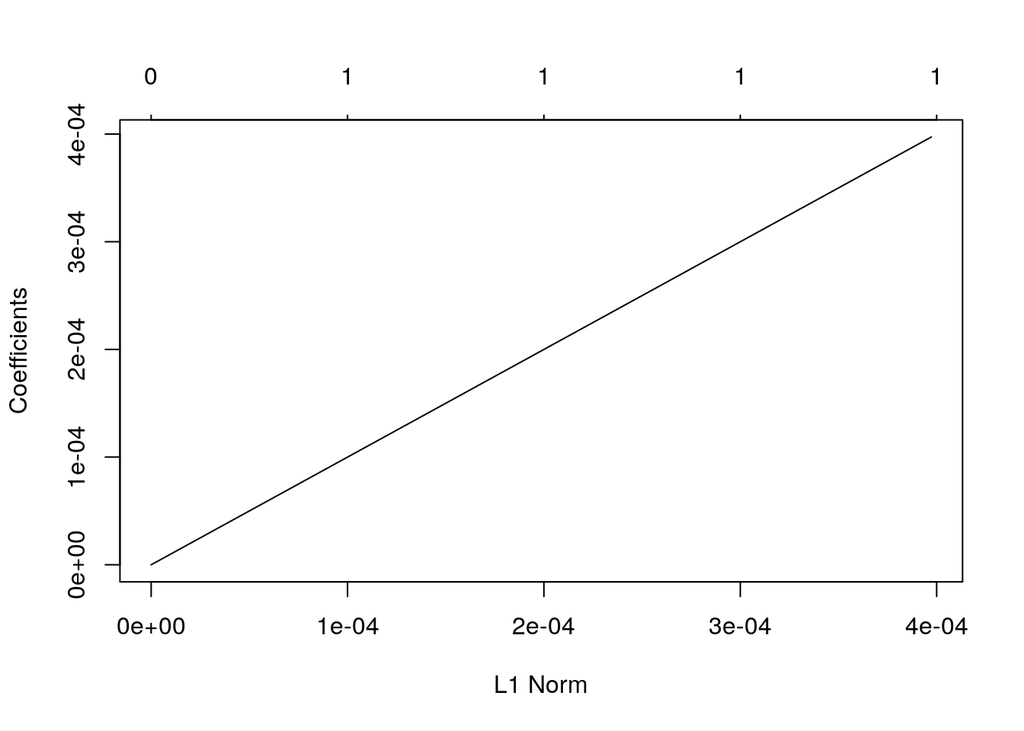

```r
mylrLasso <- glmnet(x=trainDataMM,
                    y=trainData$TARGET,
                    intercept=FALSE,
                    family="binomial")
plot(mylrLasso)
```

Fit a LASSO model for all interaction terms with centered and scaled data. The “best” value of lambda is for the model with 44 terms.

```r
mylrLassoCV <-  cv.glmnet(x=trainDataMMScale,
                                     y=trainData$TARGET,
                                     intercept=FALSE,
                                     family="binomial",
                                     nfolds=5)

mylrLassoCV$lambda.min
```

```
## [1] 0.001852639
```

```r
mylrLassoFinal <- glmnet(x=trainDataMMScale,
                    y=trainData$TARGET,
                    intercept=FALSE,
                    family="binomial",
                    lambda=mylrLassoCV$lambda.min)


mylrLassoFinalVars <- which(mylrLassoFinal$beta[,ncol(mylrLassoFinal$beta)] != 0)
mylrLassoFinalBeta <- mylrLassoFinal$beta[mylrLassoFinalVars]

length(mylrLassoFinalVars)
```

```
## [1] 44
```

```r
mylrLassoFinalVars
```

```
##                                                  BEDS
##                                                     2
##                                                 BATHS
##                                                     3
##                                           SQUARE.FEET
##                                                     4
##                                              LOT.SIZE
##                                                     5
##                                            YEAR.BUILT
##                                                     6
##                                        DAYS.ON.MARKET
##                                                     7
##                                        X..SQUARE.FEET
##                                                     8
##                                             HOA.MONTH
##                                                     9
##                PROPERTY.TYPESingle Family Residential
##                                                    13
##                                PROPERTY.TYPETownhouse
##                                                    14
##                  PROPERTY.TYPEMulti-Family (2-4 Unit)
##                                                    15
##                                   BEDS:DAYS.ON.MARKET
##                                                    22
##                                   BEDS:X..SQUARE.FEET
##                                                    23
##                                        BEDS:HOA.MONTH
##                                                    24
##                                         BEDS:LATITUDE
##                                                    25
##                                     BATHS:SQUARE.FEET
##                                                    33
##                                      BATHS:YEAR.BUILT
##                                                    35
##                                  BATHS:DAYS.ON.MARKET
##                                                    36
##                                        BATHS:LATITUDE
##                                                    39
##                          BATHS:PROPERTY.TYPETownhouse
##                                                    43
```

[output cut: 33 more lines]

```
##                                                    98
##       HOA.MONTH:PROPERTY.TYPEMobile/Manufactured Home
##                                                   104
##                      HOA.MONTH:PROPERTY.TYPETownhouse
##                                                   106
##        HOA.MONTH:PROPERTY.TYPEMulti-Family (2-4 Unit)
##                                                   107
##                          HOA.MONTH:PROPERTY.TYPEOther
##                                                   109
##       LATITUDE:PROPERTY.TYPESingle Family Residential
##                                                   112
##                       LATITUDE:PROPERTY.TYPETownhouse
##                                                   113
##         LATITUDE:PROPERTY.TYPEMulti-Family (2-4 Unit)
##                                                   114
```

```r
mylrLassoFinalBeta
```

```
##  [1] -2.890375e-01  3.031296e-01  1.146361e+00 -8.943897e-02  4.241030e-01
##  [6] -1.044646e-03  5.290317e+00  5.749563e-01  1.430265e+00  1.789647e-01
## [11]  3.695877e+00 -2.680703e-01  3.575696e-02 -3.305519e-01  6.883577e-02
## [16] -3.086730e-01  2.785917e-01  2.208032e-01 -2.845744e-01  2.027576e-01
## [21]  6.991678e-02  2.360204e+00 -2.981345e-01  5.128318e-01  4.653633e+00
## [26]  4.604497e+00 -2.030762e+02 -1.540691e+02 -3.037674e+01  6.868380e-01
## [31] -1.149905e-02 -2.387647e-01 -4.185881e-04 -6.404574e-01 -7.244253e-01
## [36]  5.851709e+00  3.653405e+00 -9.728244e+00 -3.148549e+00 -2.652354e+00
## [41] -8.668030e-01 -3.983986e-02  3.135485e-01 -1.796840e-01
```

```r
mylrLassoPredict <- predict(mylrLassoFinal,
                            newx=testDataMMScale,
                            type="response")

mylrLassoPred <- prediction(mylrLassoPredict[,1],
                            testData$TARGET,
                            label.ordering = c("Below", "Above"))
mylrLassoAUC <- performance(mylrLassoPred, "auc")
mylrLassoPerf <- performance(mylrLassoPred, "tpr", "fpr")
mylrLassoAUC@y.values[[1]]
```

```
## [1] 0.9798054
```

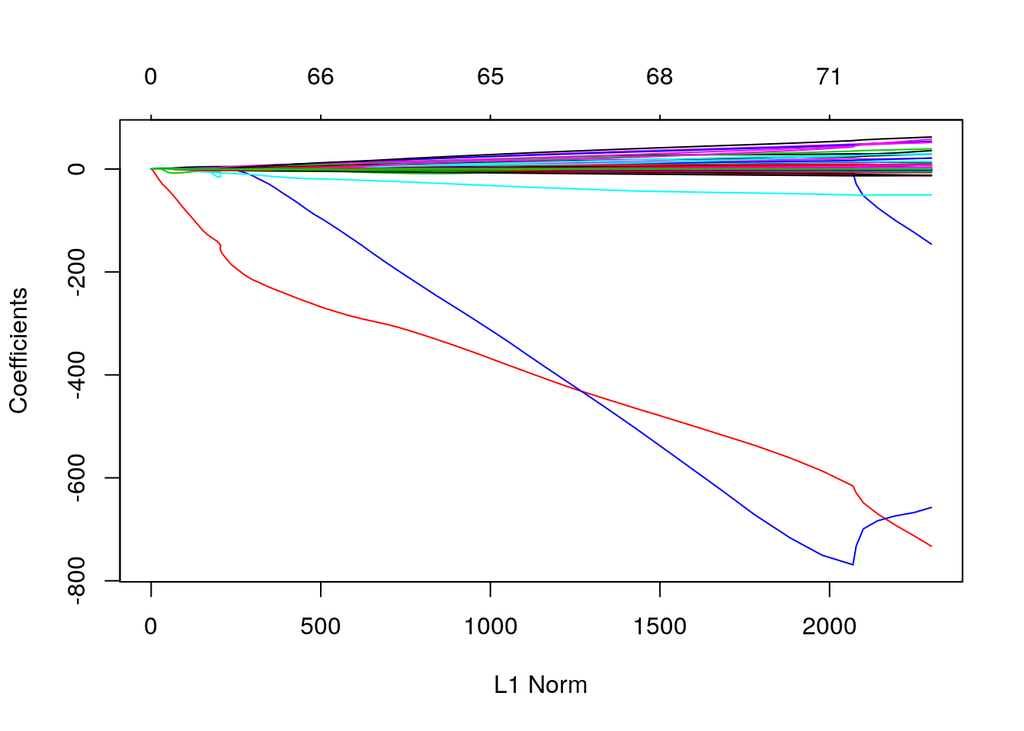

```r
mylrLasso <- glmnet(x=trainDataMMScale,
                    y=trainData$TARGET,
                    intercept=FALSE,
                    family="binomial")
plot(mylrLasso)
```

```r
write.table(as.matrix(mylrLasso$beta),file="betas.csv", sep=",")
```

## Random GLM

Random GLM with up to order 2 interactions.

```r
library(randomGLM)

myRandomGLM <- randomGLM(x=trainDataMMNoInt,
                    y=trainData$TARGET,
                    xtest = testDataMMNoInt,
                    maxInteractionOrder = 2,
                    classify=TRUE)
myRandomGLMPred <- prediction(myRandomGLM$predictedTest.response[,2],
                              testData$TARGET,
                              label.ordering=c("Below","Above")
                              )
myRandomGLMAUC <- performance(myRandomGLMPred, "auc")
myRandomGLMPerf <- performance(myRandomGLMPred, "tpr", "fpr")
myRandomGLMAUC@y.values[[1]]
```

```
## [1] 0.9999733
```

```r
myRandomGLM$timesSelectedByForwardRegression
```

```
##         (Intercept) BEDS BATHS SQUARE.FEET LOT.SIZE YEAR.BUILT
## Level.1           2    1     6           3        1          0
## Level.2          30   24    71          86       21         35
##         DAYS.ON.MARKET X..SQUARE.FEET HOA.MONTH LATITUDE LONGITUDE
## Level.1              1              5         0        0         0
## Level.2             12             88        17       25        36
##         PROPERTY.TYPEMobile/Manufactured Home
## Level.1                                     0
## Level.2                                    12
##         PROPERTY.TYPESingle Family Residential PROPERTY.TYPETownhouse
## Level.1                                      1                      1
## Level.2                                     16                     19
##         PROPERTY.TYPEMulti-Family (2-4 Unit)
## Level.1                                    0
## Level.2                                   20
##         PROPERTY.TYPEMulti-Family (5+ Unit) PROPERTY.TYPEOther
## Level.1                                   0                  1
## Level.2                                  21                 18
```

Count number of times out of 100 bags each term is selected in a model. The active interaction term occurs in 50 of the bags. Several other degree 2 terms are used as well.

```r
myRandomGLMNames <- sapply(myRandomGLM$featuresInForwardRegression,
                           function(x) colnames(x))
table(unlist(myRandomGLMNames))
```

```
##
##                                                    BATHS
##                                                        7
##                                        BATHS.times.BATHS
##                                                        7
##                                         BATHS.times.BEDS
##                                                        1
##                                     BATHS.times.LATITUDE
##                                                        4
##                                    BATHS.times.LONGITUDE
##                                                       14
##                                  BATHS.times.SQUARE.FEET
##                                                        3
##                               BATHS.times.X..SQUARE.FEET
##                                                       17
##                                   BATHS.times.YEAR.BUILT
##                                                        6
##                                         BEDS.times.BATHS
##                                                        1
##                                     BEDS.times.LONGITUDE
##                                                        2
##                                   BEDS.times.SQUARE.FEET
##                                                        3
##                                BEDS.times.X..SQUARE.FEET
##                                                        8
##                                     LATITUDE.times.BATHS
##                                                        5
##                               LATITUDE.times.SQUARE.FEET
##                                                        6
##                            LATITUDE.times.X..SQUARE.FEET
##                                                        9
##                                    LONGITUDE.times.BATHS
##                                                       11
##                              LONGITUDE.times.SQUARE.FEET
##                                                        7
## PROPERTY.TYPESingle.Family.Residential.times.SQUARE.FEET
##                                                        1
##                                              SQUARE.FEET
##                                                        5
##                                  SQUARE.FEET.times.BATHS
```

[output cut: 16 more lines]

```
##                                                        6
##                            X..SQUARE.FEET.times.LATITUDE
##                                                        4
##                           X..SQUARE.FEET.times.LONGITUDE
##                                                        5
##                         X..SQUARE.FEET.times.SQUARE.FEET
##                                                       37
##                          X..SQUARE.FEET.times.YEAR.BUILT
##                                                       16
##                                   YEAR.BUILT.times.BATHS
##                                                        8
##                             YEAR.BUILT.times.SQUARE.FEET
##                                                        5
##                          YEAR.BUILT.times.X..SQUARE.FEET
##                                                       19
```

# Machine Learning

We will use caret, so reorder the levels of the target.

```r
trainData$TARGET <- factor(trainData$TARGET, levels=c("Above", "Below"))
testData$TARGET <- factor(testData$TARGET, levels=c("Above", "Below"))
trainDataScale$TARGET <- factor(trainDataScale$TARGET, levels=c("Above", "Below"))
testDataScale$TARGET <- factor(testDataScale$TARGET, levels=c("Above", "Below"))
```

# Classification Tree

For a classification tree model, square footage and price per square foot are important variables. Other variables have high importance values as well. The accuracy is not as good as for many of the other models tested.

```r
myrpart <- train(TARGET ~ .,
                data = trainData,
                method="rpart",
                trControl=trainControl(classProbs=TRUE))
myrpartPredict <- predict(myrpart,
                          newdata=testData,
                          type="prob")

myrpart$finalModel$variable.importance
```

```
##                         X..SQUARE.FEET
##                             212.099520
##                            SQUARE.FEET
##                              48.436545
##                                  BATHS
##                              30.170912
##                                   BEDS
##                              28.050794
##                              HOA.MONTH
##                              23.954593
##                               LATITUDE
##                              19.529568
## PROPERTY.TYPESingle Family Residential
##                              14.840827
##                 PROPERTY.TYPETownhouse
##                               9.855848
##                              LONGITUDE
##                               6.335903
##                               LOT.SIZE
##                               6.335903
```

```r
myrpartPred <- prediction(myrpartPredict[,1],
                        testData$TARGET,
                        label.ordering=c("Below","Above"))
myrpartAUC <- performance(myrpartPred, "auc")
myrpartPerf <- performance(myrpartPred, "tpr", "fpr")
myrpartAUC@y.values[[1]]
```

```
## [1] 0.8803434
```

## The Support Vector Machine

Using scaled data.

Support vector machine with a linear kernel.

```r
mysvmLinear <- train(TARGET ~ .,
                     data = trainDataScale,
                     method="svmLinear",
                     trControl=trainControl(classProbs=TRUE))

mysvmLinearPredict <- predict(mysvmLinear, newdata=testDataScale)

mysvmLinearPredict <- predict(mysvmLinear,
                                 newdata=testDataScale,
                                 type="prob")

mysvmLinearPred <- prediction(mysvmLinearPredict[,1],
                                 testDataScale$TARGET,
                                 label.ordering=c("Below","Above"))
mysvmLinearAUC <- performance(mysvmLinearPred, "auc")
mysvmLinearPerf <- performance(mysvmLinearPred, "tpr", "fpr")
mysvmLinearAUC@y.values[[1]]
```

```
## [1] 0.9824987
```

Support vector machine with a polynomial kernel.

```r
mysvmPoly <- train(TARGET ~ .,
                   data=trainDataScale,
                   method="svmPoly",
                   trainControl=c(classProbs=TRUE))

mysvmPolyPredict <- predict(mysvmPoly,
                               newdata=testDataScale,
                               type="prob")
# getting probabilities fails, so get point predictions
mysvmPolyPredict <- predict(mysvmPoly,
                               newdata=testDataScale)


# calculate AUC based on 0/1 predictions
mysvmPolyPred <- prediction(-as.numeric(mysvmPolyPredict)+2,
                               testDataScale$TARGET,
                               label.ordering=c("Below", "Above"))
mysvmPolyAUC <- performance(mysvmPolyPred, "auc")
mysvmPolyPerf <- performance(mysvmPolyPred, "tpr", "fpr")
mysvmPolyAUC@y.values[[1]]
```

```
## [1] 0.9317308
```

```r
mysvmRbf <- train(TARGET ~ .,
                  data=trainDataScale,
                  method="svmRadial",
                  trainControl=c(classProbs=TRUE))


## getting probabilities fails, so use the point prediction
#mysvmRbfPredict <- predict(mysvmRbf,
#                               newdata=testDataScale,
#                               type="prob")

mysvmRbfPredict <- predict(mysvmRbf,
                               newdata=testDataScale)


# calculate AUC based on 0/1 predictions
mysvmRbfPred <- prediction(-as.numeric(mysvmRbfPredict)+2,
                               testDataScale$TARGET,
                               label.ordering=c("Below", "Above"))
mysvmRbfAUC <- performance(mysvmRbfPred, "auc")
mysvmRbfPerf <- performance(mysvmRbfPred, "tpr", "fpr")
mysvmRbfAUC@y.values[[1]]
```

```
## [1] 0.8927809
```

## Neural Network

```r
mynnet <- train(x=trainDataScale[,-ncol(trainDataScale)],
                   y=trainDataScale$TARGET,
                   method="nnet",
                   trControl=trainControl(classProbs=TRUE))
mynnet
```

```
## Neural Network
##
## 1001 samples
##   11 predictor
##    2 classes: 'Above', 'Below'
##
## No pre-processing
## Resampling: Bootstrapped (25 reps)
## Summary of sample sizes: 1001, 1001, 1001, 1001, 1001, 1001, ...
## Resampling results across tuning parameters:
##
##   size  decay  Accuracy   Kappa
##   1     0e+00  0.9455363  0.8734631
##   1     1e-04  0.9473910  0.8771322
##   1     1e-01  0.9489992  0.8812681
##   3     0e+00  0.9511869  0.8864238
##   3     1e-04  0.9493684  0.8822876
##   3     1e-01  0.9656016  0.9197372
##   5     0e+00  0.9499621  0.8839817
##   5     1e-04  0.9501058  0.8840271
##   5     1e-01  0.9608854  0.9089371
##
## Accuracy was used to select the optimal model using the largest value.
## The final values used for the model were size = 3 and decay = 0.1.
```

```r
mynnetPredict <- predict(mynnet, newdata=testDataScale[,-ncol(testDataScale)], type="prob")

mynnetPred <- prediction(mynnetPredict[,1],
                            testDataScale$TARGET,
                            label.ordering=c("Below", "Above"))
mynnetAUC <- performance(mynnetPred, "auc")
mynnetPerf <- performance(mynnetPred, "tpr", "fpr")
mynnetAUC@y.values[[1]]
```

```
## [1] 0.9961532
```

Variable importance.

```r
garson(mynnet$finalModel, bar_plot=FALSE)
```

```
##                                             rel_imp
## BEDS                                   0.0316856826
## BATHS                                  0.0301748210
## SQUARE.FEET                            0.2517161780
## LOT.SIZE                               0.0079088177
## YEAR.BUILT                             0.0426633494
## DAYS.ON.MARKET                         0.0250197608
## X..SQUARE.FEET                         0.3443477630
## HOA.MONTH                              0.0532123890
## LATITUDE                               0.0340463832
## LONGITUDE                              0.0423598312
## PROPERTY.TYPEMobile/Manufactured Home  0.0343411045
## PROPERTY.TYPESingle Family Residential 0.0400142071
## PROPERTY.TYPETownhouse                 0.0273259443
## PROPERTY.TYPEMulti-Family (2-4 Unit)   0.0323338266
## PROPERTY.TYPEMulti-Family (5+ Unit)    0.0000382454
## PROPERTY.TYPEOther                     0.0028116964
```

## Random Forest

```r
myrf <- train(x=trainDataScale[,-ncol(trainDataScale)],
                   y=trainDataScale$TARGET,
                   method="rf",
                   trControl=trainControl(classProbs=TRUE))

myrfPredict <- predict(myrf,
                          newdata=testDataScale[,-ncol(testDataScale)],
                          type="prob")

myrfPred <- prediction(myrfPredict[,1],
                          testDataScale$TARGET,
                          label.ordering=c("Below", "Above"))
myrfAUC <- performance(myrfPred, "auc")
myrfPerf <- performance(myrfPred, "tpr", "fpr")
myrfAUC@y.values[[1]]
```

```
## [1] 0.9963179
```

Variable importance.

```r
myrf$finalModel$importance
```

```
##                MeanDecreaseGini
## BEDS                   8.761646
## BATHS                 36.055749
## SQUARE.FEET          123.843297
## LOT.SIZE               3.609696
## YEAR.BUILT             8.619012
## DAYS.ON.MARKET         5.408765
## X..SQUARE.FEET       210.292244
## HOA.MONTH              7.577656
## LATITUDE              10.453528
## LONGITUDE             10.515283
## PROPERTY.TYPE          3.146667
```

# ROC Curves

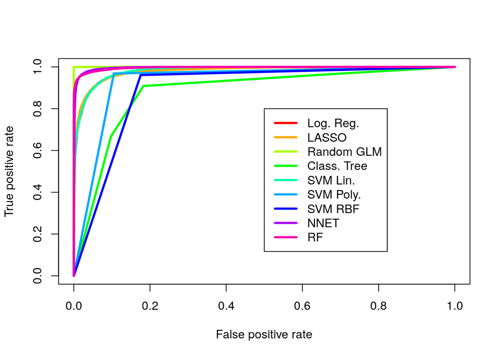

```r
library(colorspace)
predictions <- matrix(c(mylrPredict,
                        mylrLassoPredict[,1],
                        myRandomGLM$predictedTest.response[,2],
                        myrpartPredict[,1],
                        mysvmLinearPredict[,1],
                        -as.numeric(mysvmPolyPredict)+2,
                        -as.numeric(mysvmRbfPredict)+2,
                        mynnetPredict[,1],
                        myrfPredict[,1]), ncol=9)
pred_matrix <- prediction(predictions,
                          labels=matrix(testDataScale$TARGET,
                                        nrow=nrow(predictions),
                                        ncol=9),
                          label.ordering=c("Below", "Above"))

perf_matrix <- performance(pred_matrix, "tpr", "fpr")
plot(perf_matrix, col=as.list(rainbow(9)), lwd=3)

legend(0.5, 0.8, c("Log. Reg.",
                   "LASSO",
                   "Random GLM",
                   "Class. Tree",
                   "SVM Lin.",
                   "SVM Poly.",
                   "SVM RBF",
                   "NNET",
                   "RF"), col=rainbow(9), lwd=3)
```

# CONJECTURING

## Property 1

$\textrm{bathrooms} \geq -\textrm{threeHundredK}/\textrm{pricePerSquareFoot} + \textrm{squareFootage} \rightarrow \textrm{isBelow}$

Check using the first derived property as a classification rule by itself. By the nature of the proposed method, there are no errors on the training data.

```r
conjFeatureTrain <- factor(ifelse(trainData$BATHS >= -300000/trainData$X..SQUARE.FEET + trainData$SQUARE.FEET,
                                  "Below",
                                  "Above"),
                           levels=c("Below", "Above"))
table(trainData$TARGET, conjFeatureTrain)
```

```
##        conjFeatureTrain
##         Below Above
##   Above     0   690
##   Below   311     0
```

On the test data, there are 37 errors out of 30,156 houses.

```r
conjFeatureTest <- factor(ifelse(testData$BATHS >= -300000/testData$X..SQUARE.FEET + testData$SQUARE.FEET,
                                 "Below",
                                 "Above"),
                          levels=c("Below", "Above"))
table(testData$TARGET, conjFeatureTest)
```

```
##        conjFeatureTest
##         Below Above
##   Above    10 20770
##   Below  9349    27
```

An inspection of the misclassified houses reveals that the mis-classifications were due to rounding error and/or mis-coding of the data. For example, there is a house with 31,248 bathrooms.

```r
testData$PRICE <- mydata$PRICE[-trainRows]
testData %>%
    dplyr::filter(TARGET != conjFeatureTest) %>%
    dplyr::select(TARGET, X..SQUARE.FEET, SQUARE.FEET, BATHS, PRICE) %>%
    dplyr::mutate(SQFT.TIMES.PRICEPERSQFT = X..SQUARE.FEET*SQUARE.FEET)
```

```
##    TARGET X..SQUARE.FEET SQUARE.FEET   BATHS   PRICE
## 1   Below             76        3962     2.5  299900
## 2   Below            207        1452     1.0  299900
## 3   Above            172        1742     2.5  300283
## 4   Below            133        2262     3.0  299900
## 5   Below            182        1652     3.5  299900
## 6   Below            105        2868     4.0  300000
## 7   Above            153        2400 31248.0  366000
## 8   Below            187        1608     2.5  300000
## 9   Below            143        2100     2.0  299900
## 10  Below            164        1834     2.0  300000
## 11  Above            231        2114  3131.0  489000
## 12  Below            162        1855     3.0  299900
## 13  Above            191        6174 12876.0 1180000
## 14  Above            307         976     2.0  300043
```

[output cut: 61 more lines]

## Property 2

$\textrm{squareFootage} \geq (\textrm{threeHundredK}+1)/(\textrm{pricePerSquareFoot} - 1) \rightarrow \textrm{isAbove}$

Check using the first derived property as a classification rule by itself. As with the other property, there are no errors on the training data.

```r
conjFeatureTrain2 <- factor(ifelse(trainData$SQUARE.FEET >= (300000+1)/(trainData$X..SQUARE.FEET - 1),
                                  "Above",
                                  "Below"),
                           levels=c("Below", "Above"))
table(trainData$TARGET, conjFeatureTrain2)
```

```
##        conjFeatureTrain2
##         Below Above
##   Above     0   690
##   Below   311     0
```

On the test data, there are 26 errors out of 30,156 houses.

```r
conjFeatureTest2 <- factor(ifelse(testData$SQUARE.FEET >= (300000+1)/(testData$X..SQUARE.FEET - 1),
                                 "Above",
                                 "Below"),
                          levels=c("Below", "Above"))
table(testData$TARGET, conjFeatureTest2)
```

```
##        conjFeatureTest2
##         Below Above
##   Above    24 20756
##   Below  9374     2
```

An inspection of the misclassified houses reveals that the mis-classifications were due to rounding error and/or mis-coding of the data. For example, two houses had prices below $460.

```r
testData %>%
    dplyr::filter(TARGET != conjFeatureTest2) %>%
    dplyr::select(TARGET, X..SQUARE.FEET, SQUARE.FEET, BATHS, PRICE) %>%
    dplyr::mutate(SQFT.TIMES.PRICEPERSQFT = X..SQUARE.FEET*SQUARE.FEET)
```

```
##    TARGET X..SQUARE.FEET SQUARE.FEET BATHS  PRICE SQFT.TIMES.PRICEPERSQFT
## 1   Above            172        1742  2.50 300283                  299624
## 2   Above            307         976  2.00 300043                  299632
## 3   Above            130        2319  2.00 301990                  301470
## 4   Above            151        1982  2.50 300075                  299282
## 5   Above            111        2716  2.50 301990                  301476
## 6   Above            171        1762  2.00 301990                  301302
## 7   Above            124        2432  2.50 300990                  301568
## 8   Above            171        1762  2.00 301990                  301302
## 9   Above            121        2500  3.50 302490                  302500
## 10  Above            123        2441  3.00 300648                  300243
## 11  Above            129        2336  2.50 300700                  301344
## 12  Above            105        2883  2.50 303990                  302715
## 13  Above             97        3113  3.00 300490                  301961
## 14  Above            169        1780  3.00 301490                  300820
## 15  Above            135        2236  3.00 300880                  301860
## 16  Above             86        3526  3.00 304900                  303236
## 17  Above            140        2156  2.50 302000                  301840
## 18  Above            130        2320  2.50 301490                  301600
## 19  Above            130        2320  2.50 300490                  301600
## 20  Above            117        2566  2.50 300990                  300222
## 21  Above            119        2530  2.50 301490                  301070
## 22  Above             85        3527  3.50 300990                  299795
## 23  Above             92        3289  4.50 300990                  302588
## 24  Below              0        1248  1.75    459                       0
## 25  Above             23       13604  1.00 315000                  312892
## 26  Below              0         471  1.00     99                       0
```